# Coefficient Tables

Lio, Orestis

19 June, 2020

First, it might be good to seperate between the restriction period and the relaxation period. Let’s see if the Oxford index is capturing this difference meaningfully.

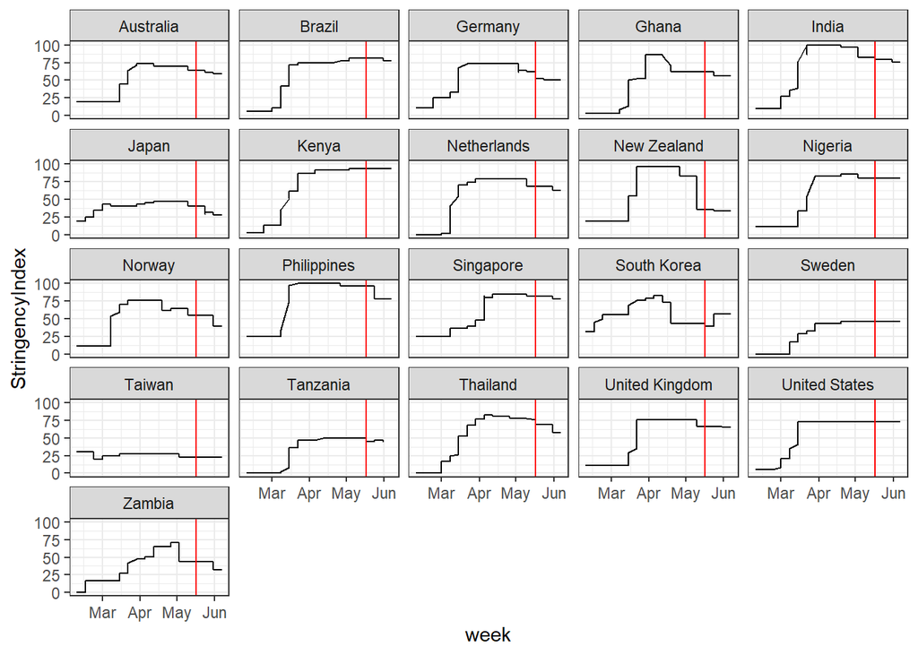

I look here only at the 21 countries for which we have information about their Long-Term Orientation. In most cases, we see a tendency to relax policies sometime around the middle of May. A more complete treatise would identify that exact date for every country. But for the sake of simplicity, I arbitrarily set the end of the first period on the 17th of May (vertical red line).

|  | COL | ROL | MAS | UAI | LTO | patience | risktaking | altruism | trust | total_cases | new_cases | total_deaths | new_deaths | Gini | GDP.capita | polity2 | StringencyIndex | LongRunCoeff_1 | LongRunCoeff_2 | LongRunCoeff_3 | cor_simple | coef_simple |
| --- | --- | --- | --- | --- | --- | --- | --- | --- | --- | --- | --- | --- | --- | --- | --- | --- | --- | --- | --- | --- | --- | --- |
| COL | 1 | -0.645 | -0.103 | 0.276 | 0.269 | -0.736 | -0.021 | 0.034 | -0.198 | -0.358 | -0.211 | -0.452 | -0.287 | 0.507 | -0.705 | -0.274 | 0.278 | 0.011 | -0.032 | -0.125 | -0.116 | -0.108 |
| ROL | -0.645 | 1 | -0.157 | -0.226 | 0.174 | 0.712 | -0.069 | -0.047 | 0.193 | 0.186 | 0.068 | 0.242 | 0.132 | -0.409 | 0.813 | 0.339 | -0.3 | -0.069 | -0.039 | -0.002 | 0.198 | -0.024 |
| MAS | -0.103 | -0.157 | 1 | 0.072 | 0.177 | -0.123 | -0.063 | -0.071 | -0.085 | 0.116 | 0.085 | 0.125 | 0.122 | 0.14 | -0.065 | -0.047 | 0.104 | -0.139 | -0.16 | -0.118 | -0.324 | -0.383 |
| UAI | 0.276 | -0.226 | 0.072 | 1 | 0.521 | -0.429 | -0.413 | -0.098 | -0.349 | -0.093 | -0.082 | -0.07 | -0.089 | 0.025 | -0.281 | 0.054 | 0.105 | 0.018 | -0.06 | -0.079 | -0.092 | -0.258 |
| LTO | 0.269 | 0.174 | 0.177 | 0.521 | 1 | -0.125 | -0.827 | 0.073 | -0.263 | -0.096 | 0.041 | -0.127 | -0.014 | -0.064 | 0.016 | -0.015 | -0.332 | -0.109 | -0.038 | -0.106 | 0.485 | 0.036 |
| patience | -0.736 | 0.712 | -0.123 | -0.429 | -0.125 | 1 | 0.259 | -0.01 | 0.189 | 0.333 | 0.188 | 0.375 | 0.274 | -0.319 | 0.833 | 0.33 | -0.254 | 0.034 | -0.009 | 0.035 | 0.265 | 0.213 |
| risktaking | -0.021 | -0.069 | -0.063 | -0.413 | -0.827 | 0.259 | 1 | -0.047 | -0.042 | 0.004 | -0.028 | 0 | -0.016 | 0.4 | -0.008 | -0.045 | 0.279 | -0.1 | -0.195 | -0.213 | -0.148 | 0.084 |
| altruism | 0.034 | -0.047 | -0.071 | -0.098 | 0.073 | -0.01 | -0.047 | 1 | 0.216 | 0.182 | 0.198 | 0.183 | 0.199 | 0.153 | -0.015 | -0.211 | 0.193 | -0.037 | -0.094 | -0.147 | -0.074 | -0.137 |
| trust | -0.198 | 0.193 | -0.085 | -0.349 | -0.263 | 0.189 | -0.042 | 0.216 | 1 | 0.109 | 0.069 | 0.128 | 0.091 | -0.167 | 0.251 | -0.187 | -0.092 | 0.233 | 0.182 | 0.183 | 0.029 | 0.014 |
| total_cases | -0.358 | 0.186 | 0.116 | -0.093 | -0.096 | 0.333 | 0.004 | 0.182 | 0.109 | 1 | 0.883 | 0.929 | 0.921 | 0.039 | 0.261 | 0.073 | 0.01 | -0.066 | -0.005 | -0.028 | -0.042 | -0.053 |

[output cut: 12 more lines]

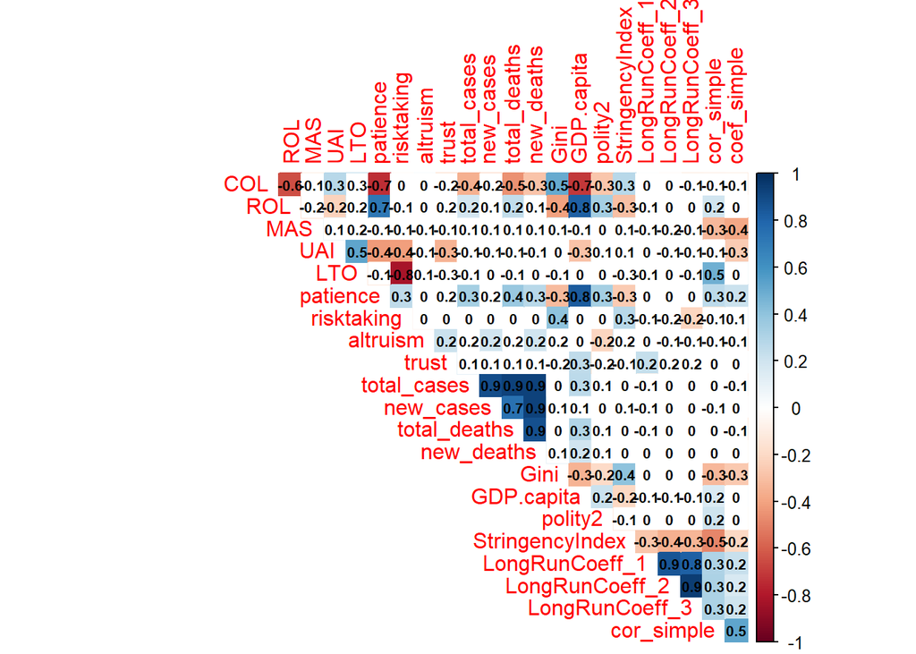

And this is the correlation table (and a heatmap visualisation) for all countries (not just the LTO ones) that we have info about movement and stringency index. An improved version would also display the number of countries that we have information of. Perhaps a geom_point plot where the size of the circle is that number. But, for now, maybe this will suffice.